# autumn-group-project-arya-jasmina-neeman

Jasmina R

2023-12-21

## Including Plots

library(tidyverse) library(janitor) library(ggplot2) library(lubridate) library(dplyr) library(here) library(kableExtra) library(rmarkdown) library(maps) library(knitr) library(grid)

ca <- read_csv(“owid-covid-data.csv”) #ca is short for covid_area head(ca)

#filter location data which removes nulls and continents ca$no_of_chars<-nchar(gsub("[^A-Z]","",ca$iso_code)) fca <- filter(ca,ca$no_of_chars < 4) #continents fca <- filter(ca,ca$no_of_chars > 1) #nulls

filter(ca,ca$new_cases > 3)

# create data for world coordinates using

# map_data() function

world_coordinates <- map_data(“world”)

fca <- rename(fca, “region” = “location”)

fca <- fca %>% group_by(region) %>% summarise(total_cases_per_million = max(total_cases_per_million,0, na.rm =T))

fca <- filter(fca, fca$total_cases_per_million > 0)

fca <- fca %>% mutate(region = recode(str_trim(region), “United States” = “USA”, “United Kingdom” = “UK”, “Congo” = “Republic of Congo”, “Democratic Republic of Congo” = “Democratic Republic of the Congo”, “Cote d’Ivoire” = “Ivory Coast”, “Czechia” = “Czech Republic”))

hello_world <- left_join(world_coordinates, fca, by = “region”) head(hello_world)

plain <- theme( axis.text = element_blank(), axis.line = element_blank(), axis.ticks = element_blank(), panel.border = element_blank(), panel.grid = element_blank(), axis.title = element_blank(), panel.background = element_rect(fill = “white”), plot.title = element_text(hjust = 0.5), )

covid_heatmap <- ggplot(data = hello_world,mapping = aes(x = long, y = lat, group = group)) + coord_fixed(1.3) + geom_polygon(aes(fill = total_cases_per_million)) + scale_fill_distiller(palette = “BuPu”, direction = 1) + ggtitle(“Covid Cases per million”) + plain

#adding in N/A annotation na_annotation <- data.frame(x = 160, y = -60, label = “N/A”, stringsAsFactors = FALSE) covid_heatmap <- covid_heatmap + annotation_custom( grob = grid::textGrob(label = na_annotation$label, just = "left", gp = gpar(fontsize = 6)), xmin = max(na_annotation$x) + 7.5, xmax = max(na_annotation$x) + 10, ymin = min(na_annotation$y), ymax = max(na_annotation$y + 5) ) + annotation_custom(grob = rectGrob(gp = gpar(fill = "darkgrey")), xmin = max(na_annotation$x), xmax = max(na_annotation$x) + 5, ymin = min(na_annotation$y), ymax = max(na_annotation$y) + 5) covid_heatmap

[output not shown]

[output not shown]

[output not shown]

[output not shown]

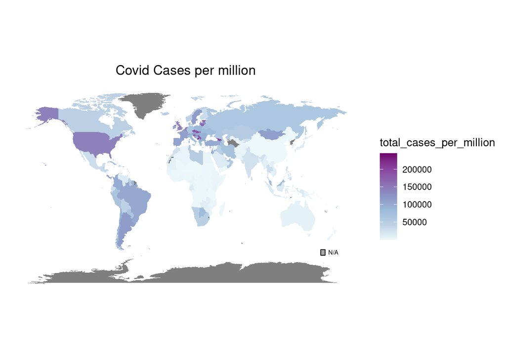

[output not shown]

[output not shown]

[figure not shown]